# Replication 2: DiD

Amelia Hund & Minna Heim

2023-03-14

# REPLICATION 2: Difference in Differences

### Preparations

```r
# Load data
card <-
  read_csv("Card_Krueger_AER_1994_data.csv", show_col_types = FALSE) %>%
  mutate(state = fct_relevel(state, "Pennsylvania", after = 0))

summary(card)
```

```
##      sheet           after        chain                    state
##  Min.   :  1.0   Min.   :0.0   Length:798         Pennsylvania:156
##  1st Qu.:116.5   1st Qu.:0.0   Class :character   New Jersey  :642
##  Median :236.0   Median :0.5   Mode  :character
##  Mean   :246.1   Mean   :0.5
##  3rd Qu.:374.5   3rd Qu.:1.0
##  Max.   :522.0   Max.   :1.0
##
##      ncalls         empft            emppt           nmgrs
##  Min.   :0.00   Min.   : 0.000   Min.   : 0.00   Min.   : 1.000
##  1st Qu.:0.00   1st Qu.: 2.000   1st Qu.:11.00   1st Qu.: 3.000
##  Median :1.00   Median : 6.000   Median :17.00   Median : 3.000
##  Mean   :1.42   Mean   : 8.361   Mean   :18.92   Mean   : 3.483
##  3rd Qu.:2.00   3rd Qu.:12.000   3rd Qu.:25.00   3rd Qu.: 4.000
##  Max.   :9.00   Max.   :60.000   Max.   :60.00   Max.   :10.000
##  NA's   :248    NA's   :13       NA's   :9       NA's   :8
##     wage_st         inctime         firstin           meals
##  Min.   :4.250   Min.   : 2.00   Min.   :0.0000   Min.   :0.000
##  1st Qu.:4.500   1st Qu.:13.00   1st Qu.:0.1500   1st Qu.:2.000
##  Median :5.000   Median :19.00   Median :0.2000   Median :2.000
##  Mean   :4.809   Mean   :20.05   Mean   :0.2216   Mean   :1.841
##  3rd Qu.:5.050   3rd Qu.:26.00   3rd Qu.:0.2500   3rd Qu.:2.000
##  Max.   :6.250   Max.   :52.00   Max.   :1.0000   Max.   :3.000
##  NA's   :31      NA's   :86      NA's   :112
##       open           hrsopen          psoda            pfry
##  Min.   : 0.000   Min.   : 7.00   Min.   :0.410   Min.   :0.6700
##  1st Qu.: 6.500   1st Qu.:12.00   1st Qu.:1.000   1st Qu.:0.8500
##  Median : 7.000   Median :15.00   Median :1.050   Median :0.9400
##  Mean   : 8.081   Mean   :14.45   Mean   :1.045   Mean   :0.9314
##  3rd Qu.:10.500   3rd Qu.:16.00   3rd Qu.:1.090   3rd Qu.:1.0100
##  Max.   :11.500   Max.   :24.00   Max.   :1.490   Max.   :1.3700
##  NA's   :1        NA's   :1       NA's   :20      NA's   :35
##     pentree          nregs          nregs11
##  Min.   :0.410   Min.   :1.000   Min.   :0.000
##  1st Qu.:0.940   1st Qu.:3.000   1st Qu.:2.000
##  Median :1.035   Median :3.000   Median :3.000
##  Mean   :1.343   Mean   :3.609   Mean   :2.691
##  3rd Qu.:2.000   3rd Qu.:4.000   3rd Qu.:3.000
##  Max.   :3.950   Max.   :8.000   Max.   :7.000
##  NA's   :26      NA's   :17      NA's   :28
```

# Question 1: Implementation of the minimum wage

## a) Distribution of starting wage rates before MW (by state)

Produce one figure showing the distribution of starting wage rates by state before the MW increase (February 1992).

```r
# rounding the values in the starting wage column, so that our bin size replicates the one in the study more closely
card$wage_st <- round(card$wage_st/.05)*.05

#trying to do this with bar chart:
df_plot_1 <- card %>%
             filter(after == 0) %>%
             group_by(state, wage_st) %>%
             summarise(total_count = n(), .groups = "drop_last") %>%
             mutate(percent = total_count / sum(total_count))

head(df_plot_1)
```

```
## # A tibble: 6 × 4
## # Groups:   state [1]
##   state        wage_st total_count percent
##   <fct>          <dbl>       <int>   <dbl>
## 1 Pennsylvania    4.25          26  0.333
## 2 Pennsylvania    4.35           1  0.0128
## 3 Pennsylvania    4.5           12  0.154
## 4 Pennsylvania    4.65           1  0.0128
## 5 Pennsylvania    4.75          10  0.128
## 6 Pennsylvania    4.85           1  0.0128
```

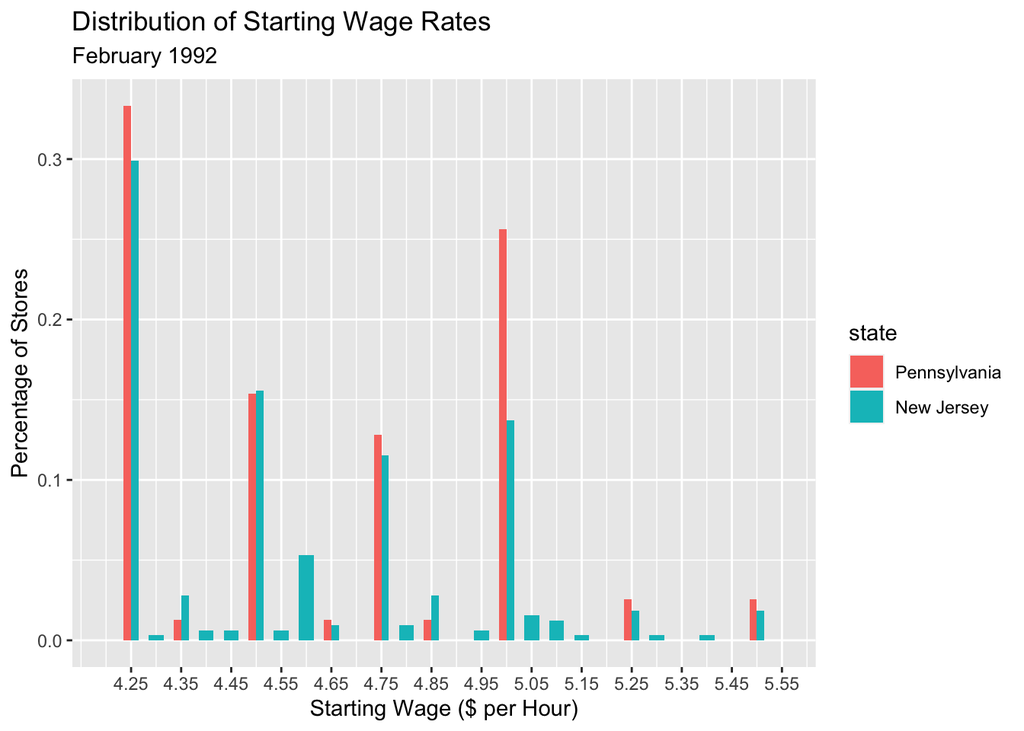

```r
x <- seq(from = 4.25, to = 5.55, by = 0.1)

plot_1  <-  df_plot_1 %>%
            ggplot(aes(x = wage_st, y = percent, fill = state)) +
            geom_bar(position = "dodge", stat = "identity", width = 0.03) +
            labs(title = "Distribution of Starting Wage Rates", subtitle = "February 1992", x = "Starting Wage ($ per Hour)", y = "Percentage of Stores") +
            scale_x_continuous(breaks = x, limits = c(4.20, 5.55))
plot_1
```

## b) Distribution of starting wage rates after MW (by state)

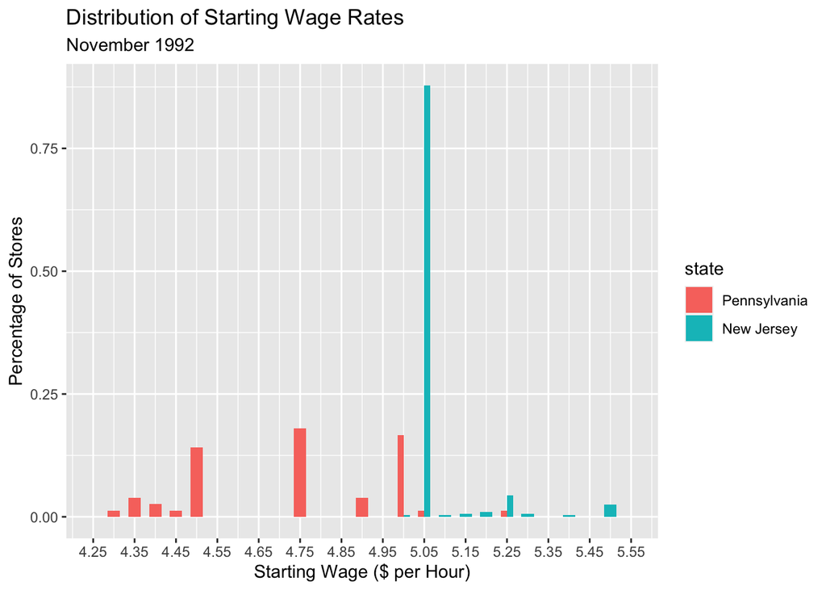

```r
#trying to do this with bar chart:
df_plot_2 <- card %>%
             filter(after == 1) %>%
             group_by(state, wage_st) %>%
             summarise(total_count = n(), .groups = "drop_last") %>%
             mutate(percent = total_count / sum(total_count))

x <- seq(from = 4.25, to = 5.55, by = 0.1)

plot_2  <-  df_plot_2 %>%
            ggplot(aes(x = wage_st, y = percent, fill = state)) +
            geom_bar(position = position_dodge(), stat = "identity", width = 0.03) +
            labs(title = "Distribution of Starting Wage Rates", subtitle = "November 1992", x = "Starting Wage ($ per Hour)", y = "Percentage of Stores") +
            scale_x_continuous(breaks = x, limits = c(4.25, 5.55))
plot_2
```

## c) Conclusion

Bar plots 1 and 2 show the distributions of starting wages in the two states before and after the rise.

In wave 1, the distributions of starting wages in New Jersey and Pennsylvania were very similar. By wave 2, however, virtually all restaurants in New Jersey that had been paying less than 5.05 dollars per hour reported a starting wage equal to the new rate. We can see this in bar plot 2. Almost all fast-food restaurants that previously paid less than the new minimum wage of 5.05 dollars per hour now shifted to the right and chose to pay the minimum wage (except for one restaurant, see below). We can see this in the large increase of the relative frequency of fast-food restaurants in New Jersey now paying 5.05 to 5.15 dollars per hour. Therefore, it seems as if the minimum wage increase was implemented successfully.

```r
# Search for stores that did not implement the minimum wage increase:
no_mw <- card %>%
  filter(state == "New Jersey") %>%
  filter(after == 1) %>%
  filter(wage_st < 5.05)

head(no_mw)
```

```
## # A tibble: 1 × 19
##   sheet after chain state ncalls empft emppt nmgrs wage_st inctime firstin meals
##   <dbl> <dbl> <chr> <fct>  <dbl> <dbl> <dbl> <dbl>   <dbl>   <dbl>   <dbl> <dbl>
## 1    13     1 KFC   New …      1     2    11     3       5      13    0.25     1
## # … with 7 more variables: open <dbl>, hrsopen <dbl>, psoda <dbl>, pfry <dbl>,
## #   pentree <dbl>, nregs <dbl>, nregs11 <dbl>
```

Through this small chunk of code, we see that only one store did not implement the minimum wage increase.

# Question 2: Descriptive statistics

## a) Wave 1 (before MW increase)

###(The test of equaltiy of means for a and b is included in c!)

The first step is to analyze the key variables from a descriptive perspective. For this question, focus exclusively on the following four variables: FTE employment, starting wage, price of full meal, and hours open.

Consider the first wave only (before the MW increase). Prepare a table with mean values of the four variables by state. Perform a test of equality of means between the two states.

```r
D <- card %>%
  mutate(fte = empft + nmgrs + 0.5 * emppt) %>%
  mutate(fullmeal = psoda + pfry + pentree)

D
```

```
## # A tibble: 798 × 21
##    sheet after chain      state ncalls empft emppt nmgrs wage_st inctime firstin
##    <dbl> <dbl> <chr>      <fct>  <dbl> <dbl> <dbl> <dbl>   <dbl>   <dbl>   <dbl>
##  1     1     0 Burger Ki… New …      0  16      30     4    4.5       NA   0.25
##  2     1     1 Burger Ki… New …     NA  20      40     4    5.05      NA  NA
##  3     2     0 Burger Ki… New …      0  10       6     3    4.75      26   0.5
##  4     2     1 Burger Ki… New …     NA   7.5    10     3    5.25      19   0.38
##  5     3     0 KFC        New …      3   6      13     3    4.25      13   0.25
##  6     3     1 KFC        New …      2   4       7     3    5.05      26   0.25
##  7     4     0 Roy Rogers New …      0  10      12     3    4.75       4   0.25
##  8     4     1 Roy Rogers New …     NA   5      30     4    5.05      26   0.28
##  9     5     0 Roy Rogers New …      0   5      30     4    4.5       13   0.17
## 10     5     1 Roy Rogers New …      2  10      30     4    5.15       4   0.180
## # … with 788 more rows, and 10 more variables: meals <dbl>, open <dbl>,
## #   hrsopen <dbl>, psoda <dbl>, pfry <dbl>, pentree <dbl>, nregs <dbl>,
## #   nregs11 <dbl>, fte <dbl>, fullmeal <dbl>
```

```r
j1 <- D %>%
  filter(after == 0) %>%
  filter(state == "New Jersey")


p1 <- D %>%
  filter(after == 0) %>%
  filter(state == "Pennsylvania")


j2 <- D %>%
  filter(after == 1) %>%
  filter(state == "New Jersey")


p2 <- D %>%
  filter(after ==1) %>%
  filter(state == "Pennsylvania")


wave1 <- matrix (data = c(mean(j1$fte, na.rm = TRUE),
                          mean(j1$wage_st, na.rm = TRUE),
                          mean(j1$fullmeal, na.rm = TRUE),
                          mean(j1$hrsopen, na.rm = TRUE),
                          mean(p1$fte, na.rm = TRUE),
                          mean(p1$wage_st, na.rm = TRUE),
                          mean(p1$fullmeal, na.rm = TRUE),
                          mean(p1$hrsopen, na.rm =TRUE)), ncol = 2)

Wave1 <- as.data.frame(wave1)


colnames(Wave1) <-  c("New Jersey Averages", "Pennsylvania Averages")
rownames(Wave1) <- c("FTE", "Starting Wage", "Full Meal",  "Hours Open")


Wave1_fin <- Wave1 %>%
  kbl(digits=3) %>%
  kable_minimal()

Wave1_fin
```

|  | New Jersey Averages | Pennsylvania Averages |
| --- | --- | --- |
| FTE | 20.595 | 23.395 |
| Starting Wage | 4.612 | 4.631 |
| Full Meal | 3.362 | 3.044 |
| Hours Open | 14.419 | 14.545 |

## b) Wave 2 (after MW increase)

```r
Wave2 <- as.data.frame(matrix(data = c(mean(j2$fte, na.rm = TRUE),
                                       mean(j2$wage_st, na.rm = TRUE),
                                       mean(j2$fullmeal, na.rm = TRUE),
                                       mean(j2$hrsopen, na.rm = TRUE),
                                       mean(p2$fte, na.rm = TRUE),
                                       mean(p2$wage_st, na.rm = TRUE),
                                       mean(p2$fullmeal, na.rm = TRUE),
                                       mean(p2$hrsopen, na.rm = TRUE)), ncol = 2))

colnames(Wave2) <-  c("New Jersey Averages", "Pennsylvania Averages")
rownames(Wave2) <- c("FTE",  "Starting Wage", "Full Meal", "Hours Open")

Wave2 %>%
  kbl(digits=3) %>%
  kable_minimal()
```

|  | New Jersey Averages | Pennsylvania Averages |
| --- | --- | --- |
| FTE | 21.362 | 21.444 |
| Starting Wage | 5.081 | 4.618 |
| Full Meal | 3.417 | 3.027 |
| Hours Open | 14.415 | 14.654 |

```r
# calculating percentage increase of starting wage: (we refer to this in our conclusion)
  (5.081-4.614)/4.614
```

```
## [1] 0.1012137
```

## c) Differences between NJ and PA

### Wave 1:

```r
#testing for significance
#Wave 1:

t1 <- t.test(fte      ~ state, data = filter(D, after == 0))
t1
```

```
##
##  Welch Two Sample t-test
##
## data:  fte by state
## t = 1.9144, df = 97.609, p-value = 0.0585
## alternative hypothesis: true difference in means between group Pennsylvania and group New Jersey is not equal to 0
## 95 percent confidence interval:
##  -0.1026362  5.7020777
## sample estimates:
## mean in group Pennsylvania   mean in group New Jersey
##                   23.39474                   20.59502
```

```r
t2 <- t.test(wage_st  ~ state, data = filter(D, after == 0))
t2
```

```
##
##  Welch Two Sample t-test
##
## data:  wage_st by state
## t = 0.42987, df = 111.15, p-value = 0.6681
## alternative hypothesis: true difference in means between group Pennsylvania and group New Jersey is not equal to 0
## 95 percent confidence interval:
##  -0.07035586  0.10933831
## sample estimates:
## mean in group Pennsylvania   mean in group New Jersey
##                   4.631333                   4.611842
```

```r
t3 <- t.test(fullmeal ~ state, data = filter(D, after == 0)) #H0 rejected
t3
```

```
##
##  Welch Two Sample t-test
##
## data:  fullmeal by state
## t = -4.0149, df = 120.4, p-value = 0.0001038
## alternative hypothesis: true difference in means between group Pennsylvania and group New Jersey is not equal to 0
## 95 percent confidence interval:
##  -0.4753497 -0.1613669
## sample estimates:
## mean in group Pennsylvania   mean in group New Jersey
##                   3.044133                   3.362492
```

```r
t4 <- t.test(hrsopen  ~ state, data = filter(D, after == 0))
t4
```

```
##
##  Welch Two Sample t-test
##
## data:  hrsopen by state
## t = 0.33996, df = 112.59, p-value = 0.7345
## alternative hypothesis: true difference in means between group Pennsylvania and group New Jersey is not equal to 0
## 95 percent confidence interval:
##  -0.6076865  0.8594239
## sample estimates:
## mean in group Pennsylvania   mean in group New Jersey
##                   14.54487                   14.41900
```

```r
ttests <- map_df(list(t1, t2, t3, t4), tidy)
ttests
```

```
## # A tibble: 4 × 10
##   estim…¹ estim…² estim…³ stati…⁴ p.value param…⁵ conf.…⁶ conf.…⁷ method alter…⁸
##     <dbl>   <dbl>   <dbl>   <dbl>   <dbl>   <dbl>   <dbl>   <dbl> <chr>  <chr>
## 1  2.80     23.4    20.6    1.91  5.85e-2    97.6 -0.103    5.70  Welch… two.si…
## 2  0.0195    4.63    4.61   0.430 6.68e-1   111.  -0.0704   0.109 Welch… two.si…
## 3 -0.318     3.04    3.36  -4.01  1.04e-4   120.  -0.475   -0.161 Welch… two.si…
## 4  0.126    14.5    14.4    0.340 7.35e-1   113.  -0.608    0.859 Welch… two.si…
## # … with abbreviated variable names ¹estimate, ²estimate1, ³estimate2,
## #   ⁴statistic, ⁵parameter, ⁶conf.low, ⁷conf.high, ⁸alternative
```

```r
ttests = subset(ttests, select =c("estimate", "statistic", "p.value", "conf.low", "conf.high"))

ttests_df <- as.data.frame(ttests)

rownames(ttests_df)<- c("FTE", "Minimum Wage", "Price of Full meal", "Hours open")

ttests_df %>%
  kbl %>%
  kable_minimal()
```

|  | estimate | statistic | p.value | conf.low | conf.high |
| --- | --- | --- | --- | --- | --- |
| FTE | 2.7997208 | 1.9143864 | 0.0584994 | -0.1026362 | 5.7020777 |
| Minimum Wage | 0.0194912 | 0.4298705 | 0.6681221 | -0.0703559 | 0.1093383 |
| Price of Full meal | -0.3183583 | -4.0149068 | 0.0001038 | -0.4753497 | -0.1613669 |
| Hours open | 0.1258687 | 0.3399587 | 0.7345210 | -0.6076865 | 0.8594239 |

### Wave 2:

```r
#Wave 2:


tt1<- t.test(fte      ~ state, data = filter(D, after == 1))
tt2<- t.test(wage_st  ~ state, data = filter(D, after == 1)) #rejected
tt3<- t.test(fullmeal ~ state, data = filter(D, after == 1)) #rejected
tt4<- t.test(hrsopen  ~ state, data = filter(D, after == 1))

tt1
```

```
##
##  Welch Two Sample t-test
##
## data:  fte by state
## t = 0.078355, df = 125.42, p-value = 0.9377
## alternative hypothesis: true difference in means between group Pennsylvania and group New Jersey is not equal to 0
## 95 percent confidence interval:
##  -1.984701  2.148337
## sample estimates:
## mean in group Pennsylvania   mean in group New Jersey
##                   21.44408                   21.36226
```

```r
tt2
```

```
##
##  Welch Two Sample t-test
##
## data:  wage_st by state
## t = -10.827, df = 72.685, p-value < 2.2e-16
## alternative hypothesis: true difference in means between group Pennsylvania and group New Jersey is not equal to 0
## 95 percent confidence interval:
##  -0.5485983 -0.3780201
## sample estimates:
## mean in group Pennsylvania   mean in group New Jersey
##                   4.617606                   5.080915
```

```r
tt3
```

```
##
##  Welch Two Sample t-test
##
## data:  fullmeal by state
## t = -5.1033, df = 114.96, p-value = 1.333e-06
## alternative hypothesis: true difference in means between group Pennsylvania and group New Jersey is not equal to 0
## 95 percent confidence interval:
##  -0.5416398 -0.2387392
## sample estimates:
## mean in group Pennsylvania   mean in group New Jersey
##                   3.026620                   3.416809
```

```r
tt4
```

```
##
##  Welch Two Sample t-test
##
## data:  hrsopen by state
## t = 0.6626, df = 112.74, p-value = 0.5089
## alternative hypothesis: true difference in means between group Pennsylvania and group New Jersey is not equal to 0
## 95 percent confidence interval:
##  -0.4756387  0.9536435
## sample estimates:
## mean in group Pennsylvania   mean in group New Jersey
##                   14.65385                   14.41484
```

```r
ttests2 <- map_df(list(tt1, tt2, tt3, tt4), tidy)

ttests2
```

```
## # A tibble: 4 × 10
##   estimate estimate1 estimate2 statistic  p.value param…¹ conf.…² conf.…³ method
##      <dbl>     <dbl>     <dbl>     <dbl>    <dbl>   <dbl>   <dbl>   <dbl> <chr>
## 1   0.0818     21.4      21.4     0.0784 9.38e- 1   125.   -1.98    2.15  Welch…
## 2  -0.463       4.62      5.08  -10.8    8.17e-17    72.7  -0.549  -0.378 Welch…
## 3  -0.390       3.03      3.42   -5.10   1.33e- 6   115.   -0.542  -0.239 Welch…
## 4   0.239      14.7      14.4     0.663  5.09e- 1   113.   -0.476   0.954 Welch…
## # … with 1 more variable: alternative <chr>, and abbreviated variable names
## #   ¹parameter, ²conf.low, ³conf.high
```

```r
ttests2 = subset(ttests2, select =c("estimate", "statistic", "p.value", "conf.low", "conf.high"))

ttests2_df <- as.data.frame(ttests2)
rownames(ttests2_df)<- c("FTE", "Minimum Wage", "Price of Full meal", "Hours open")



ttests2_df %>%
  kbl %>%
  kable_minimal()
```

|  | estimate | statistic | p.value | conf.low | conf.high |
| --- | --- | --- | --- | --- | --- |
| FTE | 0.0818178 | 0.0783551 | 0.9376704 | -1.9847009 | 2.1483365 |
| Minimum Wage | -0.4633092 | -10.8271938 | 0.0000000 | -0.5485983 | -0.3780201 |
| Price of Full meal | -0.3901895 | -5.1032775 | 0.0000013 | -0.5416398 | -0.2387392 |
| Hours open | 0.2390024 | 0.6625962 | 0.5089415 | -0.4756387 | 0.9536435 |

According to the p-values of the t tests above, the difference in means of the minimum wages (p-value: 2.2e-16) and the difference in means of price of full meals between New Jersey and Pennsylvania (p-value: 1.333e-06) are statistically significant at the 0.1, 0.05, and 0.01 - significance levels during wave 2.

CONCLUSION AND DISCUSSION OF THREAT TO VALIDITY:

In wave 1, average employment was 23.395 full-time equivalent workers per store in Pennsylvania, compared with an average of 20.595 in New Jersey. Starting wages were very similar among stores in the two states, although the average price of a “full meal” (medium soda, small fries, and an entree) was significantly higher in New Jersey. There were no significant cross-state differences in average hours of operation.

The average starting wage at fast-food restaurants in New Jersey increased by 10 percent (refer to 2b) following the rise in the minimum wage. Further insight into this change is provided in Figure 1 (exercise 1), which shows the distributions of starting wages in the two states before and after the rise. As stated previously, in wave 1, the distributions in New Jersey and Pennsylvania were very similar. By wave 2 virtually all restaurants in New Jersey that had been paying less than $5.05 per hour reported a starting wage equal to the new rate.

Despite the increase in wages, full-time- equivalent employment increased in New Jersey relative to Pennsylvania. Whereas New Jersey stores were initially smaller, employment gains in New Jersey coupled with losses in Pennsylvania led to a small and statistically insignificant interstate difference in wave 2.

In the absence of treatment, so wave 1, treatment and control groups may differ. However, what is important is not that the difference in means between New Jersey and Pennsylvania is statistically insignificant, but rather, that they move in parallel. This pattern opens the door to DiD estimation of causal effects. The whole reason for the DiD approach is that we compare changes in differences of means instead of levels, thus, eliminating fixed differences between groups that might otherwise generate omitted variable bias. Hence, Difference-in-difference is a useful technique to use when randomization on the individual level is not possible. The approach removes biases in post-intervention period comparisons between the treatment and control group that could be the result from permanent differences between those groups, as well as biases from comparisons over time in the treatment group that could be the result of trends due to other causes of the outcome.

The identifying assumption thereby is parallel trends. The assumption of parallel trends can also be expressed as:
$$E(Y_{02} - Y_{01}|D = 1) = E(Y_{02} - Y_{01}|D =
0)$$
. Only if this assumption holds, we can approximate the selection affect
$$E(Y_{02}|D=1) -
E(Y_{02}|D=0)$$
in the second period prima facie contrast before treatment via the difference in observed means of $Y_1$ for D = 1 and D = 0 (treated and non-treated):
$$E(Y_{01}|D=1) - E(Y_{01}|D=0)
= E(Y_1|D=1) - E(Y_1|D=0)$$
. We then subtract this selection effect from the difference in observed means of $Y_2$ for D = 1 and D = 0: $E(Y_2|D=1) - E(Y_2|D=0)$. The DiD estimator is then
$$E(Y_2|D=1) -
E(Y_2|D=0)-[E(Y_1|D=1)-E(Y_1|D=0)] = E(Y_{12} - Y_{02}|D=1)$$
. This identifies the ATET if the time trend in the non-treated outcome is independent of the treatment.

Based on our explanation preceding the deep dive into the theory, these differences do not pose a threat to the validity in the DiD framework.

We could already calculate the DiD manually using tables Wave1 and Wave2 in exercise 2b.

```r
#manual calculation of difference in fte of control state Pennsylvania between wave 2 and 1:
23.395 - 21.444
```

```
## [1] 1.951
```

```r
#manual calculation of difference in fte of treatment state New Jersey between wave 2 and 1:
20.595 - 21.362
```

```
## [1] -0.767
```

```r
#subtract differences
(23.395 - 21.444)-(20.595 - 21.362)
```

```
## [1] 2.718
```

In the following exercise we see, that we get the same result using a simple DiD regression.

# Question 3: Estimation of the effect via DiD

## a) Estimate a simple DiD model without covariates and use robust SEs

```r
#Create a dummy variable to identify the group exposed to the treatment. We assume New Jersey was treated (=1)
D$treated = ifelse(D$state == "New Jersey",1, 0)

#Create an interaction between time ( variable = after) and treated. We will call this interaction did.
D$did = D$treated*D$after

D
```

```
## # A tibble: 798 × 23
##    sheet after chain      state ncalls empft emppt nmgrs wage_st inctime firstin
##    <dbl> <dbl> <chr>      <fct>  <dbl> <dbl> <dbl> <dbl>   <dbl>   <dbl>   <dbl>
##  1     1     0 Burger Ki… New …      0  16      30     4    4.5       NA   0.25
##  2     1     1 Burger Ki… New …     NA  20      40     4    5.05      NA  NA
##  3     2     0 Burger Ki… New …      0  10       6     3    4.75      26   0.5
##  4     2     1 Burger Ki… New …     NA   7.5    10     3    5.25      19   0.38
##  5     3     0 KFC        New …      3   6      13     3    4.25      13   0.25
##  6     3     1 KFC        New …      2   4       7     3    5.05      26   0.25
##  7     4     0 Roy Rogers New …      0  10      12     3    4.75       4   0.25
##  8     4     1 Roy Rogers New …     NA   5      30     4    5.05      26   0.28
##  9     5     0 Roy Rogers New …      0   5      30     4    4.5       13   0.17
## 10     5     1 Roy Rogers New …      2  10      30     4    5.15       4   0.180
## # … with 788 more rows, and 12 more variables: meals <dbl>, open <dbl>,
## #   hrsopen <dbl>, psoda <dbl>, pfry <dbl>, pentree <dbl>, nregs <dbl>,
## #   nregs11 <dbl>, fte <dbl>, fullmeal <dbl>, treated <dbl>, did <dbl>
```

```r
didreg = lm(fte ~ treated + after + did, data = D) %>%
  coeftest(vcov = vcov, type ="HC0")

tidy(didreg, conf.int = TRUE)
```

```
## # A tibble: 4 × 7
##   term        estimate std.error statistic  p.value conf.low conf.high
##   <chr>          <dbl>     <dbl>     <dbl>    <dbl>    <dbl>     <dbl>
## 1 (Intercept)    23.4       1.06     22.0  1.40e-83   21.3      25.5
## 2 treated        -2.80      1.19     -2.36 1.86e- 2   -5.13     -0.469
## 3 after          -1.95      1.50     -1.30 1.95e- 1   -4.90      1.00
## 4 did             2.72      1.68      1.62 1.06e- 1   -0.576     6.01
```

```r
didregrobust <- lm(fte ~ treated + after + did, data = D)

robust <- function(mod) {

  # Compute cluster-robust SE and shorten model output
  coeftest(mod, vcov = vcovCL, cluster = ~ treated, type = "HC0") %>%
    broom::tidy() %>%
    filter(str_detect(term, "treated", negate = TRUE))
}

col1 <- robust(didregrobust)
col1
```

```
## # A tibble: 3 × 5
##   term        estimate std.error statistic p.value
##   <chr>          <dbl>     <dbl>     <dbl>   <dbl>
## 1 (Intercept)    23.4   1.24e-13   1.88e14       0
## 2 after          -1.95  1.50e-13  -1.30e13       0
## 3 did             2.72  1.50e-13   1.81e13       0
```

Therefore, we find that the increase in the minimum wage increased employment which is contradictory to the central prediction of the textbook model of the minimum wage, that a rise in New Jersey’s minimum wage would reduce employment at fast-food restaurants in the state.

## b) Elasticity

```r
Datamodel <- D %>%
  select(treated, after, did)
Datamodel
```

```
## # A tibble: 798 × 3
##    treated after   did
##      <dbl> <dbl> <dbl>
##  1       1     0     0
##  2       1     1     1
##  3       1     0     0
##  4       1     1     1
##  5       1     0     0
##  6       1     1     1
##  7       1     0     0
##  8       1     1     1
##  9       1     0     0
## 10       1     1     1
## # … with 788 more rows
```

```r
didreg1 = lm(fte ~ treated + after + did, data = D)
y_hat <- predict(didreg1, newdata = Datamodel)
head(y_hat)
```

```
##        1        2        3        4        5        6
## 20.59502 21.36226 20.59502 21.36226 20.59502 21.36226
```

```r
mean(y_hat)
```

```
## [1] 21.26029
```

```r
#D$did
#y_hat
beta_hat <- col1[3,2]
elasticity <- beta_hat* mean((D$did/y_hat), na.rm = TRUE)
elasticity
```

```
##     estimate
## 1 0.05117866
```

The estimated elasticity of employment with respect to the minimum wage increase is 0.0511. This means that if the minimum wage is increased by 1%, then the fte is increased by roughly 0.0511%. This is extremely inelastic and therefore, not economically significant, since fte is not affected significantly from variation in the minimum wage. In simple words, there is less change in fte due to minimum wage fluctuation.

# Question 4: Discussion of the identification strategy

In the case at hand, Card & Krueger’s identification strategy leverages a difference in difference design. Internal validity can be defined as the degree of confidence that the causal relationship we have tested is not influenced by other factors or variables. Therefore, as previously explained in exercise 2, the identifying assumption thereby is parallel trends. If this assumption does not hold, there are threats to internal validity (for a more in-depth explanation of this theory please refer back to exercise 2c.)

Possible threats to internal validity could for instance include demand shocks in New Jersey: If this were the case, one could argue that even in the absence of treatment, full time employment could increase in New Jersey due to a positive demand shock. Other threats to internal validity could include seasonal employment effect. However, since seasonal patterns of employment are similar in New Jersey and eastern Pennsylvania, the comparative methodology effectively “differences out” any seasonal employment effects. Furthermore, the authors of the study also included wage variation across stores in New Jersey, which allowed them to compare experiences of high-wage and low-wage stores within New Jersey and to test the validity of the Pennsylvania control group, thus removing the effect of any demand shocks.

Another possible threat to internal validity is: workers switch from part-time to full-time positions at lower wage restaurants; are thus, weighted more strongly (0.5 to 1) and consequently increase fte, however, this switch may not be due to the wage increase.